# Introduction to Ecological Trajectory Analysis

Miquel De Cáceres, Anthony Sturbois, Nicolas Djeghri

EMF-CREAF, VivArmor Nature, LEMAR

# Outline

1. Introduction
2. Conceptual and geometric elements
3. Trajectory objects
4. Characterizing trajectories
5. Comparing target states to reference trajectories
6. Comparing pairs of trajectories
7. Variation in ecological dynamics
8. Transforming trajectories

[figure not shown]

M.C. Escher - Dragon, 1952

# 1. Introduction

## About Ecological Trajectory Analysis

**What is Ecological Trajectory Analysis?**

Ecological Trajectory Analysis (ETA) is a framework to analyze the dynamics of ecological entities (e.g. communities or ecosystems).

**History of ETA**

- In 2019, De Cáceres et al, presented **Community Trajectory Analysis (CTA)** as a framework for trajectory analysis in community ecology.
- The initial framework was extended with new metrics and visualisation modes in Sturbois et al. (2021a).
- The same framework was applied to stable isotope data in Sturbois et al. (2021b), referring to it as **Stable Isotope Trajectory Analysis (SITA)**.
- Recently, the framework has been extended to cyclical data (Djeghri et al. in prep.), under the name of **Cyclical Ecological Trajectory Analysis (CETA)**.

**Flexibility**

Since it can be applied to multiple target entities and multivariate spaces, we collectively refer to the framework as **Ecological Trajectory Analysis (ETA)**.

1. Introduction

## Package **ecotraj**

[figure not shown]

The ETA framework is implemented in package **ecotraj**:

**Installation**

Package **ecotraj** (ver. 1.0.0) is distributed from [CRAN](https://cran.r-project.org/web/packages/ecotraj/index.html) and can be installed using:

```r
install.packages("ecotraj")
```

More frequent updates can be obtained if installing from **GitHub** (compilation tools are required):

```r
remotes::install_github("emf-creaf/ecotraj")
```

**Documentation**

Although the package comes with function documentation, the complete function reference and articles explaining how to use the package can be found at https://emf-creaf.github.io/ecotraj/.

**Loading**

We begin by loading **ecotraj** (ver. 1.1.0) to the workspace:

```r
library(ecotraj)
```

1. Introduction

# 2. Conceptual and geometric elements

## Conceptual elements

The most important *conceptual* elements of ETA are:

| Element | Notation | Description |
| --- | --- | --- |
| *Target entity* |  | The ecological entity whose dynamics are of interest. It can be an individual, a population, a community or an entire ecosystem |
| *Ecological observation* | $\mathbf{o}$ | The assessment of the state of a target entity, normally implying multiple attributes, at a given point in time. We also use the word observation to refer to the pair including the ecological state an… |
| *Survey* |  | An indication of the order of ecological observations (e.g. first, second, …), sometimes taken as a surrogate of linear time. |
| *Ecological state* | $\mathbf{x}$ | The feature values of a target entity when assessed at given point in time. In practice, it corresponds to an (implicit or explicit) position in $\Omega_0$. |
| *Multivariate state space* | $\Omega_0$ | The multidimensional space of ecological states. While $\Omega_0$ could be defined by explicit orthogonal axes, in ETA it is defined by calculating the dissimilarity ($d$) between all pairs of states. |
| *Time* | $t$ | The position of a given ecological observation in a (linear) temporal axis (i.e. ‘when’ the assessment act occurred). |

**Note**

Recurrent or cyclical time is another conceptual element in [Cyclical Ecological Trajectory Analysis (CETA)](https://emf-creaf.github.io/ecotraj/articles/IntroductionCETA.html).

2. Conceptual and geometric elements

## Geometric elements

The most important *geometric* elements of ETA are:

| Element | Notation | Description |
| --- | --- | --- |
| *Ecological state* | $\mathbf{x}$ | The position of an observation in space $\Omega_0$. |
| *Directed segment* | $\mathbf{s}$ | A pair of time-ordered ecological states. |
| *Ecological observation* | $\mathbf{o}$ | A pair including the ecological state $\mathbf{x}$ and the assessment time $t$, i.e. $\mathbf{o} = \{ \mathbf{x}, t \}$. |
| *Ecological trajectory* | $\mathbf{T}$ | A trajectory of size $n$ is defined as the set of $n$ time-ordered ecological observations. Alternatively, $\mathbf{T}$ can be defined as a set of $n - 1$ directed segments. |
| *Trajectory path* |  | A continuous function $f_T: [0,1]$ into $\Omega_0$, defining all points of the trajectory $\mathbf{T}$ from $f_T(0) = x_1$ to $f_T(1) = x_n$. The path includes the ecological states derived from ecolo… |
| *Ecological sub-trajectory* |  | A trajectory derived from a time-ordered subset of the observations of its parent trajectory. |
| *Trajectory section* |  | A trajectory describing a subset of its parent trajectory path. |

**Note**

Other geometry elements are defined in [Cyclical Ecological Trajectory Analysis (CETA)](https://emf-creaf.github.io/ecotraj/articles/IntroductionCETA.html).

2. Conceptual and geometric elements

# 3. Trajectory objects

## Trajectory data inputs

Trajectory data inputs for ETA are:

1. Trajectory metadata describing entities and observations.
2. A distance matrix $\mathbf{D}$ representing the resemblance between all pairs of ecological states.

**Metadata**

In this session we will primarily use a small data set where three entities have been observed four times:

```r
entities <- c("1","1","1","1","2","2","2","2","3","3","3","3")
times <- c(1.0,2.0,3.0,4.0,1.0,1.75,2.5,3.25,1.0,1.5,2.0,2.5)
```

**Distance matrix**

We will assume that ecological states can be compared using the *Euclidean distance* and only two variables have been measured:

```r
xy<-matrix(0, nrow=12, ncol=2)
xy[2,2]<-1
xy[3,2]<-2
xy[4,2]<-3
xy[5:6,2] <- xy[1:2,2]
xy[7,2]<-1.5
xy[8,2]<-2.0
xy[5:6,1] <- 0.25
xy[7,1]<-0.5
xy[8,1]<-1.0
xy[9:10,1] <- xy[5:6,1]+0.25
xy[11,1] <- 1.0
xy[12,1] <-1.5
xy[9:10,2] <- xy[5:6,2]
xy[11:12,2]<-c(1.25,1.0)
```

The distance matrix is obtained using:

```r
d <- dist(xy)
```

3. Trajectory objects

## Creating trajectory objects

Dynamic information is contained in objects of class `trajectories`.

To build them, we need to combine the distance matrix ($\mathbf{D}$) and the entity/survey information in a single object using function `defineTrajectories()`:

```r
x <- defineTrajectories(d, entities)
```

The function returns an object (a list) of class `trajectories` that contains all the information for analysis:

```r
class(x)
```

```
[1] "trajectories" "list"
```

This object contains two elements:

```r
names(x)
```

```
[1] "d"        "metadata"
```

Element `d` contains the input distance matrix ($\mathbf{D}$), whereas `metadata` is a data frame including information of observations:

```r
x$metadata
```

```
   sites surveys times
1      1       1     1
2      1       2     2
3      1       3     3
4      1       4     4
5      2       1     1
6      2       2     2
7      2       3     3
8      2       4     4
9      3       1     1
10     3       2     2
11     3       3     3
12     3       4     4
```

3. Trajectory objects

## Creating trajectory objects

Note that `x` does not contain observation times (they are assumed to be equal to surveys).

In our examples we will also use another object where we include observation times:

```r
xt <- defineTrajectories(d, entities, times = times)
xt$metadata
```

```
   sites surveys times
1      1       1  1.00
2      1       2  2.00
3      1       3  3.00
4      1       4  4.00
5      2       1  1.00
6      2       2  1.75
7      2       3  2.50
8      2       4  3.25
9      3       1  1.00
10     3       2  1.50
11     3       3  2.00
12     3       4  2.50
```

One particularity of this second trajectory object `xt` is that trajectories are not synchronous (observation times are not the same across trajectories):

```r
is.synchronous(x)
```

```
[1] TRUE
```

```r
is.synchronous(xt)
```

```
[1] FALSE
```

3. Trajectory objects

## Subsetting trajectory objects

At some point in the ETA, one may desire to focus on particular trajectories or surveys. Function `subsetTrajectory()` allows subsetting objects of class `trajectories`, For example, we can decide to work with the trajectories of the second and third entities (sites):

```r
x23 <- subsetTrajectories(xt, site_selection = c("2", "3"))
x23
```

```
$d
          1         2         3         4         5         6         7
2 1.0000000
3 1.5206906 0.5590170
4 2.1360009 1.2500000 0.7071068
5 0.2500000 1.0307764 1.5000000 2.0615528
6 1.0307764 0.2500000 0.5000000 1.1180340 1.0000000
7 1.4577380 0.7905694 0.5590170 0.7500000 1.3462912 0.5590170
8 1.6007811 1.2500000 1.1180340 1.1180340 1.4142136 1.0000000 0.5590170

$metadata
  sites surveys times
1     2       1  1.00
2     2       2  1.75
3     2       3  2.50
4     2       4  3.25
5     3       1  1.00
6     3       2  1.50
7     3       3  2.00
8     3       4  2.50

attr(,"class")
[1] "trajectories" "list"
```

3. Trajectory objects

## Drawing trajectories

To begin our analysis of the three trajectories, we display them in an ordination space, using function `trajectoryPCoA()`:

```r
trajectoryPCoA(xt,
               traj.colors = c("black","red", "blue"), lwd = 2,
               time.labels = TRUE)
legend("topright", col=c("black","red", "blue"),
       legend=c("Entity 1", "Entity 2", "Entity 3"), bty="n", lty=1, lwd = 2)
```

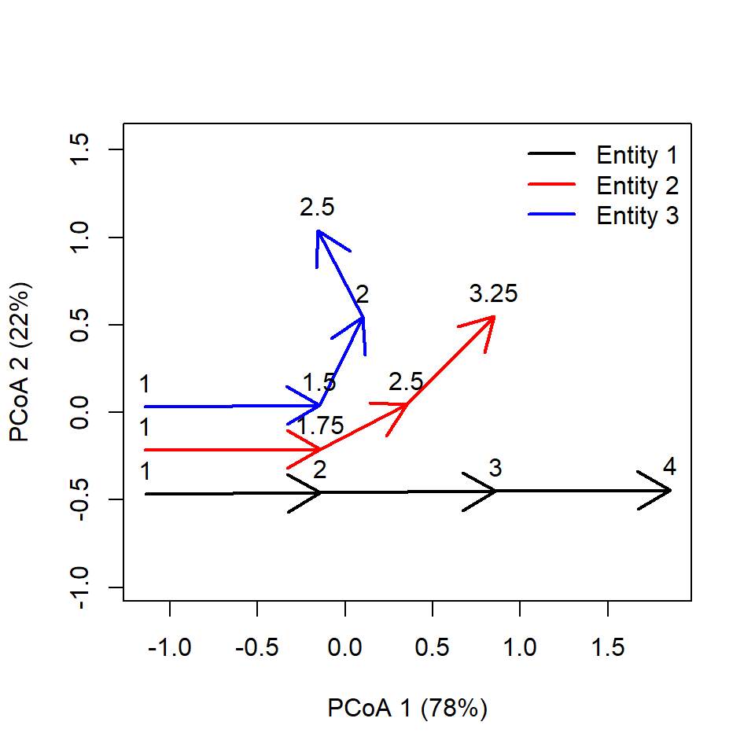

Since $\Omega_0$ has only two dimensions in this example, the Principal Coordinates Analysis (PCoA) on matrix $\mathbf{D}$ displays the complete space.

3. Trajectory objects

# 4. Characterizing trajectories

## Characterizing changes in state

| Metric | Description |
| --- | --- |
| *Segment length* | The length of a segment $\mathbf{s}$ is given by the distance between its two endpoints. |
| *Total path length* | The total path length of a trajectory $\mathbf{T}$ is the sum of the lengths of its directed segments. |
| *Segment speed* | When associated to explicit time coordinates $t_{start}$ and $t_{end}$, the speed of change of a segment $\mathbf{s}$ is defined as the length divided by its duration. |
| *Trajectory speed* | The average speed of change in trajectory $\mathbf{T}$ is estimated as the total path length divided by its duration. |
| *Net change* | For any state $\mathbf{x}_i$ of a trajectory $\mathbf{T}$, the net change is defined as the distance with respect to the initial (reference) state $\mathbf{x}_1$, i.e. $NC(\mathbf{x}_i) = d(\mathbf{x}… |
| *Trajectory sum of squares* | The sum of squares of the internal variation in the ecological states that conform trajectory $\mathbf{T}$. |
| *Trajectory internal variation* | An unbiased estimator of the internal variance in the ecological states that conform trajectory $\mathbf{T}$. |
| *Contribution of states to internal variation* | The *absolute* (sum of squares) or *relative* contributions of individual ecological states to the temporal variation in trajectory $\mathbf{T}$. |

**Note**

Combinations of these metrics can be used to estimate other metrics presented in Sturbois et al. (2021a), such as the *Net change ratio* or *Recovering or departing trajectory*.

4. Characterizing trajectories

## Characterizing changes in state

Segment/trajectory length or speed metrics are useful, for example, *to determine which entity is evolving faster* than others or *to identify periods of faster changes* within the dynamics of a single entity.

One can obtain the length of trajectory segments and the total path length:

```r
trajectoryLengths(x)
```

```
  S1       S2        S3     Path
1  1 1.000000 1.0000000 3.000000
2  1 0.559017 0.7071068 2.266124
3  1 0.559017 0.5590170 2.118034
```

In addition to segment lengths, one can also calculate the distance (i.e. the *Net change*) between all states and the initial, which is taken as reference:

```r
trajectoryLengths(x, relativeToInitial = TRUE)
```

```
  Lt1_t2   Lt1_t3   Lt1_t4     Path
1      1 2.000000 3.000000 6.000000
2      1 1.520691 2.136001 4.656692
3      1 1.346291 1.414214 3.760505
```

When observation times are available, it may be of interest to calculate segment or trajectory speeds using:

```r
trajectorySpeeds(xt)
```

```
        S1       S2       S3     Path
1 1.000000 1.000000 1.000000 1.000000
2 1.333333 0.745356 0.942809 1.007166
3 2.000000 1.118034 1.118034 1.412023
```

Finally, one may calculate the internal variation of states within each trajectory using:

```r
trajectoryInternalVariation(x)
```

```
       ss_1      ss_2      ss_3      ss_4 internal_ss internal_variance
1 2.2500000 0.2500000 0.2500000 2.2500000    5.000000         1.6666667
2 1.3281250 0.0781250 0.1406250 1.0156250    2.562500         0.8541667
3 0.8007812 0.1757812 0.2070312 0.4257813    1.609375         0.5364583
```

4. Characterizing trajectories

## Characterizing changes in direction

Since space $\Omega_0$ can include multiple dimensions, angles cannot be calculated with respect to a single plane. Instead, each angle is measured on the plane defined by a **triplet** of points.

Zero angles indicate that the three points (e.g. the two consecutive segments) are in a straight line. The larger the angle value, the more is trajectory changing in direction.

Function `trajectoryAngles()` allows calculating the angles between consecutive segments:

```r
trajectoryAngles(x)
```

```
     S1-S2    S2-S3     mean         sd       rho
1  0.00000  0.00000  0.00000 0.00000000 1.0000000
2 26.56505 18.43495 22.50000 0.07097832 0.9974842
3 63.43495 53.13010 58.28253 0.08998746 0.9959593
```

Mean and standard deviation statistics of angles are calculated according to circular statistics.

We can use the same function to calculate angles relative to the initial state:

```r
trajectoryAngles(x, relativeToInitial = TRUE)
```

```
     t1-S2    t1-S3     mean        sd       rho
1  0.00000  0.00000  0.00000 0.0000000 1.0000000
2 26.56505 35.53768 31.05136 0.0783410 0.9969360
3 63.43495 94.76364 79.09930 0.2751266 0.9628599
```

To measure the overall directionality of a trajectory (i.e. if the path consistently follows the same direction in $\Omega$ ), we recommend using function `trajectoryDirectionality()`:

```r
trajectoryDirectionality(x)
```

```
        1         2         3
1.0000000 0.8274026 0.5620859
```

4. Characterizing trajectories

## Assessing multiple metrics at once

It is possible to assess multiple trajectory metrics in one function call to `trajectoryMetrics()`. This will only provide metrics that apply to the whole trajectory:

```r
trajectoryMetrics(xt)
```

```
  trajectory n t_start t_end duration   length mean_speed mean_angle
1          1 4       1  4.00     3.00 3.000000   1.000000    0.00000
2          2 4       1  3.25     2.25 2.266124   1.007166   22.50000
3          3 4       1  2.50     1.50 2.118034   1.412023   58.28253
  directionality internal_ss internal_variance
1      1.0000000    5.000000         1.6666667
2      0.8274026    2.562500         0.8541667
3      0.5620859    1.609375         0.5364583
```

Another function, called `trajectoryWindowMetrics()` calculates trajectory metrics on moving windows over trajectories, but will not be illustrated here.

4. Characterizing trajectories

# 5. Comparing target states to reference trajectories

## Relative positions and orthogonal projection

Ecological states occupy a **relative position** within their trajectory that depends on the total path length of the trajectory.

Function `trajectoryProjection()` allows obtaining the relative position of each ecological state of a trajectory:

```r
trajectoryProjection(x$d, 1:4, 1:4)
```

```
  distanceToTrajectory segment relativeSegmentPosition
1                    0       1                       0
2                    0       1                       1
3                    0       2                       1
4                    0       3                       1
  relativeTrajectoryPosition
1                  0.0000000
2                  0.3333333
3                  0.6666667
4                  1.0000000
```

The same function can also be used to perform an **orthogonal projection** of arbitrary ecological states onto a given **reference trajectory**.

For example we can study the projection of third state of the trajectory of entity ‘2’ (i.e. state 7) onto the trajectory of entity ‘1’ (i.e. states 1 to 4), which happens to be in the half of the trajectory:

```r
trajectoryProjection(x$d, 7, 1:4)
```

```
  distanceToTrajectory segment relativeSegmentPosition
7                  0.5       2                     0.5
  relativeTrajectoryPosition
7                        0.5
```

5. Comparing states to trajectories

## Trajectory shifts

Sometimes different ecosystems follow the same or similar path but with different speeds, or with an observations starting at a different point in the dynamic sequence.

We can quantify those differences using function `trajectoryShifts()`, which internally uses orthogonal projection.

To illustrate this function, we will use a small data set of two **parallel** trajectories, but where the second is shifted:

```r
entities3 <- c("1","1","1","1","2","2","2","2")
times3 <- c(1,2,3,4,1,2,3,4)
xy3<-matrix(0, nrow=8, ncol=2)
xy3[2,2]<-1
xy3[3,2]<-2
xy3[4,2]<-3
xy3[5:8,1] <- 0.25
xy3[5:8,2] <- xy3[1:4,2] + 0.5 # States are all shifted with respect to entity "1"
x_shift <- defineTrajectories(dist(xy3), entities3, times = times3)
```

5. Comparing states to trajectories

## Trajectory shifts

We can see the differences graphically:

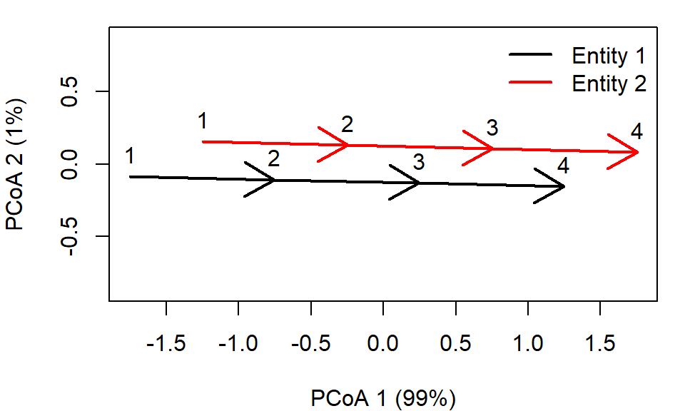

Function `trajectoryShifts()` allows comparing different observations to a reference trajectory:

```r
trajectoryShifts(x_shift)
```

```
  reference site survey time timeRef shift
1         1    2      1    1     1.5   0.5
2         1    2      2    2     2.5   0.5
3         1    2      3    3     3.5   0.5
4         1    2      4    4      NA    NA
5         2    1      1    1      NA    NA
6         2    1      2    2     1.5  -0.5
7         2    1      3    3     2.5  -0.5
8         2    1      4    4     3.5  -0.5
```

We see that the observations of trajectory “2” correspond to states of trajectory “1” at 0.5 time units later in time. Surveys with missing values indicate that the projection of the target state cannot be determined (because the reference trajectory is too short).

5. Comparing states to trajectories